# Practice Exercise CA - MBA DSA USP ESALQ

Thais Lovisi

2023-01-30

# Introduction

This exercise is my trial to reproduce the step-by-step made during the Correspondence Analysis (a.k.a reciprocal averaging) classes. The complementary file with a theoric base can be found in **.pdf** format within this project folder.

Step-by-Step to be followed:  
I. Criação da Tabela de Contingência  
II. Cálculo da frequência absoluta esperada.  
III. Cálculo da tabela de resíduos freq abs obs- freq abs esperado  
IV. Tabela com valores Qui-Quadrado e comparação com o p-valor  
V. Cálculo dos resíduos padronizados e dos resíduos padronizados ajustados  
VI. Determinar autovalores  
VII. Determinação as massas em linha e coluna  
VIII.Definição das coordenadas (scores) das categorias no mapa perceptual

### About the Data set for Simple CA (ANACOR)

```
Contains:
  Investor profile with information about investor name, investment type, and investor's profile (Conservator, Moderate or Agressive)
```

### About the Data set for MCA

```
Contains:
  Investor profile with information about investor's name, investment type, investor profile (Conservator, Moderate or Agressive), and Marital status
```

## R setup

```r
pacotes <- c("plotly", #plataforma gráfica
             "tidyverse", #carregar outros pacotes do R
             "ggrepel", #geoms de texto e rótulo para 'ggplot2' que ajudam a evitar sobreposição de textos
             "knitr", "kableExtra", #formatação de tabelas
             "sjPlot", #elaboração de tabelas de contingência
             "FactoMineR", #função 'CA' para elaboração direta da Anacor
             "amap", #funções 'matlogic' e 'burt' para matrizes binária e de Burt
             "ade4") #função 'dudi.acm' para elaboração da ACM

if(sum(as.numeric(!pacotes %in% installed.packages())) != 0){
  instalador <- pacotes[!pacotes %in% installed.packages()]
  for(i in 1:length(instalador)) {
    install.packages(instalador, dependencies = T)
    break()}
  sapply(pacotes, require, character = T)
} else {
  sapply(pacotes, require, character = T)
}
```

```
##     plotly  tidyverse    ggrepel      knitr kableExtra     sjPlot FactoMineR
##       TRUE       TRUE       TRUE       TRUE       TRUE       TRUE       TRUE
##       amap       ade4
##       TRUE       TRUE
```

### Import data

The data is in .Rdata format, thus we gonna load it directly

```r
#For the ANACOR

load(file = "perfil_investidor_aplicacao.RData")


#For MCA

load("perfil_investidor_aplicacao_estadocivil.RData")
```

## ANACOR

### Step 0- Knowing my data

```r
#Displaying the table view here
perfil_investidor_aplicacao %>%
  kable() %>%
  kable_material_dark(bootstrap_options = "striped",
                      full_width = FALSE,
                      font_size = 20)
```

| estudante | perfil | aplicacao |
| --- | --- | --- |
| Gabriela | Conservador | Poupanca |
| Luiz Felipe | Conservador | Poupanca |
| Patrícia | Conservador | Poupanca |
| Gustavo | Conservador | Poupanca |
| Letícia | Conservador | Poupanca |
| Ovídio | Conservador | Poupanca |
| Leonor | Conservador | Poupanca |
| Dalila | Conservador | Poupanca |
| Antônio | Conservador | CDB |
| Júlia | Conservador | CDB |
| Roberto | Conservador | CDB |
| Renata | Conservador | CDB |
| Guilherme | Conservador | Acoes |
| Rodrigo | Conservador | Acoes |
| Giulia | Conservador | Acoes |
| Felipe | Conservador | Acoes |
| Karina | Conservador | Acoes |
| Pietro | Moderado | Poupanca |
| Cecília | Moderado | Poupanca |
| Gisele | Moderado | Poupanca |
| Elaine | Moderado | Poupanca |
| Kamal | Moderado | Poupanca |
| Rodolfo | Moderado | CDB |
| Pilar | Moderado | CDB |
| Vivian | Moderado | CDB |
| Danielle | Moderado | CDB |
| Juliana | Moderado | CDB |
| Adriano | Moderado | CDB |
| Adelino | Moderado | CDB |
| Carolina | Moderado | CDB |

[output cut: 70 more lines]

```r
dim(perfil_investidor_aplicacao)
```

```
## [1] 100   3
```

```r
for (c in colnames(perfil_investidor_aplicacao)){ #for each col c on the range
                for (i in 1:nrow(perfil_investidor_aplicacao)){ #for each row i on the range
                    if (is.na(perfil_investidor_aplicacao[i,c])) {
                      print (c(c,"NA FOUND"))
                      break #if doesnt work with other coders go change break by next
                    }else{
                      next
                    }
                }
              }
```

This data set contains 100 rows and 3 columns, and does not contains NA values.

#### Unique values for columns to be analised

```r
  print(unique(perfil_investidor_aplicacao[,2]))
```

```
## # A tibble: 3 × 1
##   perfil
##   <fct>
## 1 Conservador
## 2 Moderado
## 3 Agressivo
```

```r
print(unique(perfil_investidor_aplicacao[,3]))
```

```
## # A tibble: 3 × 1
##   aplicacao
##   <fct>
## 1 Poupanca
## 2 CDB
## 3 Acoes
```

#### Frequencies Table

```r
summary(perfil_investidor_aplicacao)
```

```
##   estudante                 perfil      aplicacao
##  Length:100         Conservador:17   Poupanca:15
##  Class :character   Moderado   :25   CDB     :40
##  Mode  :character   Agressivo  :58   Acoes   :45
```

## Step 1- Creating the Contingency Table

Contingency Table with observed frequencies

```r
contingency_table_CA <- table(perfil_investidor_aplicacao[[2]], perfil_investidor_aplicacao[[3]])
contingency_table_CA
```

```
##
##               Poupanca CDB Acoes
##   Conservador        8   4     5
##   Moderado           5  16     4
##   Agressivo          2  20    36
```

```r
# Definition of observation number at the contingency table
n <- sum(contingency_table_CA)
n
```

```
## [1] 100
```

```r
# Chi-Square test
Chi2 <- chisq.test(x = contingency_table_CA)
Chi2
```

```
##
##  Pearson's Chi-squared test
##
## data:  contingency_table_CA
## X-squared = 31.764, df = 4, p-value = 2.138e-06
```

### Table creation

```r
# Contingency table with obs. freq
Chi2$observed
```

```
##
##               Poupanca CDB Acoes
##   Conservador        8   4     5
##   Moderado           5  16     4
##   Agressivo          2  20    36
```

```r
# Contingency table with expec. freq
Chi2$expected
```

```
##
##               Poupanca  CDB Acoes
##   Conservador     2.55  6.8  7.65
##   Moderado        3.75 10.0 11.25
##   Agressivo       8.70 23.2 26.10
```

We need to display the table as containing  
We can do so by using sjt.xtab. sjt.xtab shows contingency tables as HTML file in browser or viewer pane, or saves them as file.  
The table will be designed as Perfil x Aplicação. So for labels we will have:  
row label = Perfil (Investor’s Profile)  
column label = Aplicação (Investment Type)

```r
sjt.xtab(var.row = perfil_investidor_aplicacao$perfil,
         var.col = perfil_investidor_aplicacao$aplicacao,
         show.exp = TRUE)
```

| perfil | aplicacao |  |  | Total |  |
| --- | --- | --- | --- | --- | --- |
|  | Poupanca | CDB | Acoes |  |  |
| Conservador | 8 3 | 4 7 | 5 8 |  | 17 17 |
| Moderado | 5 4 | 16 10 | 4 11 | 25 25 |  |
| Agressivo | 2 9 | 20 23 | 36 26 | 58 58 |  |
| Total | 15 15 | 40 40 | 45 45 | 100 100 |  |

## Step 3 - Calculating the Residuals

```r
Chi2$observed - Chi2$expected
```

```
##
##               Poupanca   CDB Acoes
##   Conservador     5.45 -2.80 -2.65
##   Moderado        1.25  6.00 -7.25
##   Agressivo      -6.70 -3.20  9.90
```

A positive residual shows us that the count for that object attribute pairing is much higher than expected, suggesting a strong relationship; correspondingly, a negative residual shows a lower value than expected, suggesting a weaker relationship.

So in this step we can conclude that the pairs strong related are: Conservador and Poupança; Moderado and CDB; and Agressivo and Ações. weakly related are: Agressivo and Poupança; Moderado and Ações; and Conservador and Ações.

```r
# Chi-square per cell

((Chi2$observed - Chi2$expected)^2)/Chi2$expected
```

```
##
##                 Poupanca        CDB      Acoes
##   Conservador 11.6480392  1.1529412  0.9179739
##   Moderado     0.4166667  3.6000000  4.6722222
##   Agressivo    5.1597701  0.4413793  3.7551724
```

#### Standardized Residuals

```r
Chi2$residuals
```

```
##
##                 Poupanca        CDB      Acoes
##   Conservador  3.4129224 -1.0737510 -0.9581095
##   Moderado     0.6454972  1.8973666 -2.1615324
##   Agressivo   -2.2715127 -0.6643638  1.9378267
```

#### Standardized Residuals Adjusted

```r
Chi2$stdres
```

```
##
##                 Poupanca        CDB      Acoes
##   Conservador  4.0632908 -1.5215594 -1.4180605
##   Moderado     0.8084521  2.8284271 -3.3655013
##   Agressivo   -3.8017282 -1.3234444  4.0318926
```

For better visualization lets construct a Heat map from the residuals

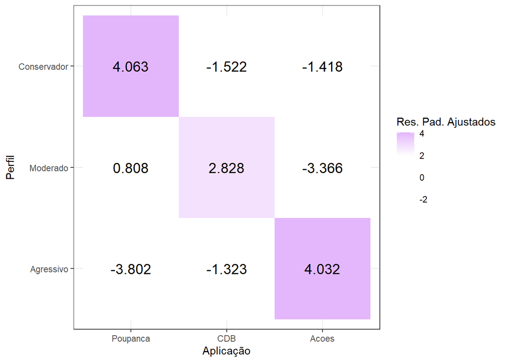

```r
data.frame(Chi2$stdres) %>%
  rename(perfil = 1,
         aplicacao = 2) %>%
  ggplot(aes(x = fct_rev(perfil), y = aplicacao,
             fill = Freq, label = round(Freq, 3))) +
  geom_tile() +
  geom_text(size = 5) +
  scale_fill_gradient2(low = "white",
                       mid = "white",
                       high = "purple",
                       midpoint = 1.96) +
  labs(x = 'Perfil', y = 'Aplicação', fill = "Res. Pad. Ajustados") +
  coord_flip() +
  theme_bw()
```

By the heatmap with Standardized Residuals Adjusted values we can conclude that the pairs strong related are: Conservador and Poupança; Moderado and CDB; Agressivo and Ações.

## Step 4- Eigenvalues (Autovalores) determination

```r
#Defining Matrix A by doing (qui2$residuals)/ sqrt(n):

matriz_A <- Chi2$residuals/sqrt(n)
matriz_A
```

```
##
##                  Poupanca         CDB       Acoes
##   Conservador  0.34129224 -0.10737510 -0.09581095
##   Moderado     0.06454972  0.18973666 -0.21615324
##   Agressivo   -0.22715127 -0.06643638  0.19378267
```

```r
#Defining Matrix W by multiplication of A for its transposed matrix (A')

matrix_W <- t(matriz_A)%*%(matriz_A)
matrix_W
```

```
##
##               Poupanca         CDB       Acoes
##   Poupanca  0.17224476 -0.00930773 -0.09067015
##   CDB      -0.00930773  0.05194320 -0.04359870
##   Acoes    -0.09067015 -0.04359870  0.09345368
```

```r
# Defining number of dimentions

numb_dim <- min(nrow(matrix_W)-1, ncol(matrix_W)-1)
numb_dim
```

```
## [1] 2
```

Dimentions quantity : 2

```r
# Defining Singulars Values


VS_AV <- svd(matriz_A, nu = numb_dim, nv = numb_dim)
VS_AV
```

```
## $d
## [1] 4.829233e-01 2.905629e-01 3.890265e-17
##
## $u
##            [,1]       [,2]
## [1,] -0.6716248  0.6155649
## [2,] -0.3980015 -0.7691520
## [3,]  0.6249119  0.1717122
##
## $v
##             [,1]       [,2]
## [1,] -0.82178847  0.4179279
## [2,] -0.09300977 -0.7689923
## [3,]  0.56215025  0.4837221
```

```r
# Singulars Values for each Dimension
valores_singulares <- VS_AV$d[1:numb_dim]
valores_singulares
```

```
## [1] 0.4829233 0.2905629
```

Axis Values X = 0,4829233 and Y = 0,2905629

```r
# Eigenvalues for each Dimension

eigenvalues <- (valores_singulares)^2
eigenvalues
```

```
## [1] 0.23321487 0.08442678
```

```r
# Principal Total Inertia (Chi-square)

inertia_tot <- as.numeric(Chi2$statistic/sum(contingency_table_CA))
inertia_tot
```

```
## [1] 0.3176416
```

```r
# Variance explained for each Dimension
var_expl <- eigenvalues/inertia_tot
var_expl
```

```
## [1] 0.7342075 0.2657925
```

```r
# Mass calculation for columns

sum_cols <- apply(contingency_table_CA, MARGIN = 1, FUN = sum)
mass_c <- sum_cols/n
mass_c
```

```
## Conservador    Moderado   Agressivo
##        0.17        0.25        0.58
```

```r
# Mass calculation for rows

sum_rows <- apply(contingency_table_CA, MARGIN = 2, FUN = sum)
mass_r <- sum_rows/n
mass_r
```

```
## Poupanca      CDB    Acoes
##     0.15     0.40     0.45
```

```r
# Eigenvectors v for dimensions
eigen_v <-VS_AV$v
eigen_v
```

```
##             [,1]       [,2]
## [1,] -0.82178847  0.4179279
## [2,] -0.09300977 -0.7689923
## [3,]  0.56215025  0.4837221
```

```r
# Eigenvectors u for dimensions
eigen_u <-VS_AV$u
eigen_u
```

```
##            [,1]       [,2]
## [1,] -0.6716248  0.6155649
## [2,] -0.3980015 -0.7691520
## [3,]  0.6249119  0.1717122
```

```r
# Summarize info from the last steps
data.frame(Dimensão = paste("Dimensão", 1:numb_dim),
           `Valor Singular` = valores_singulares,
           `Inércia Principal Parcial eigenvalues` = eigenvalues) %>%
  mutate(`Percentual da Inércia Principal Total` = (`Inércia.Principal.Parcial.eigenvalues`/inertia_tot) * 100,
         `Percentual da Inércia Principal Total Acumulada` = cumsum(`Percentual da Inércia Principal Total`),
         Chi2 = Chi2$statistic[[1]] * `Percentual da Inércia Principal Total` / n,
         `Valor Singular` = `Valor.Singular`,
         `Inércia Principal Parcial eigenvalues` = Inércia.Principal.Parcial.eigenvalues) %>%
  select(Dimensão, `Valor Singular`, `Inércia Principal Parcial eigenvalues`,
         Chi2, `Percentual da Inércia Principal Total`,
         `Percentual da Inércia Principal Total Acumulada`) %>%
  kable() %>%
  kable_styling(bootstrap_options = "striped",
                full_width = FALSE,
                font_size = 17)
```

| Dimensão | Valor Singular | Inércia Principal Parcial eigenvalues | Chi2 | Percentual da Inércia Principal Total | Percentual da Inércia Principal Total Acumulada |
| --- | --- | --- | --- | --- | --- |
| Dimensão 1 | 0.4829233 | 0.2332149 | 23.321487 | 73.42075 | 73.42075 |
| Dimensão 2 | 0.2905629 | 0.0844268 | 8.442678 | 26.57925 | 100.00000 |

## Step 4- Categories Cordinates (scores)

### To variable Perfil

```r
# Abcissas
coord_abcissas_perfil <- sqrt(valores_singulares[1]) * (mass_c^-0.5) * eigen_u[,1]
coord_abcissas_perfil
```

```
## Conservador    Moderado   Agressivo
##  -1.1319867  -0.5531638   0.5702219
```

```r
#ordenadas
coord_ordenadas_perfil <- sqrt(valores_singulares[2]) * (mass_c^-0.5) * eigen_u[,2]
coord_ordenadas_perfil
```

```
## Conservador    Moderado   Agressivo
##   0.8047656  -0.8292056   0.1215366
```

#### For columns (‘aplicacao’)

```r
# Abcissas
coord_abcissas_aplicacao <- sqrt(valores_singulares[1]) * (mass_r^-0.5) * eigen_v[,1]
coord_abcissas_aplicacao
```

```
##   Poupanca        CDB      Acoes
## -1.4745295 -0.1021969  0.5823515
```

```r
#Coordinates
coord_ordenadas_aplicacao <- sqrt(valores_singulares[2]) * (mass_r^-0.5) * eigen_v[,2]
coord_ordenadas_aplicacao
```

```
##   Poupanca        CDB      Acoes
##  0.5816688 -0.6554085  0.3886957
```

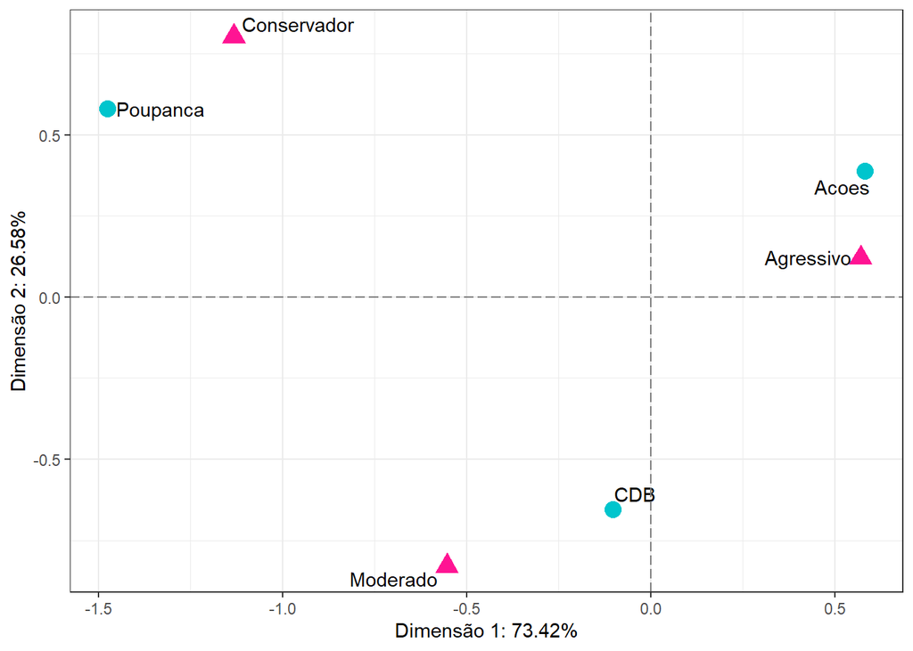

```r
# Perceptual map
cbind.data.frame(coord_abcissas_perfil, coord_ordenadas_perfil,
                 coord_abcissas_aplicacao, coord_ordenadas_aplicacao) %>%
  rename(dim_1_perfil = 1,
         dim_2_perfil = 2,
         dim_1_aplicacao = 3,
         dim_2_aplicacao = 4) %>%
  rownames_to_column() %>%
  setNames(make.names(names(.), unique = TRUE)) %>%
  mutate(aplicacao = rownames(data.frame(coord_abcissas_aplicacao,
                                         coord_ordenadas_aplicacao))) %>%
  rename(perfil = 1,
         dim_1_perfil = 2,
         dim_2_perfil = 3,
         dim_1_aplicacao = 4,
         dim_2_aplicacao = 5) %>%
  ggplot() +
  geom_point(aes(x = dim_1_perfil, y = dim_2_perfil),
             color = "deeppink1",
             fill = "deeppink1",
             shape = 24,
             size = 4) +
  geom_text_repel(aes(x = dim_1_perfil, y = dim_2_perfil, label = perfil)) +
  geom_point(aes(x = dim_1_aplicacao, y = dim_2_aplicacao),
             color = "turquoise3",
             fill = "turquoise3",
             shape = 21,
             size = 4) +
  geom_text_repel(aes(x = dim_1_aplicacao, y = dim_2_aplicacao, label = aplicacao)) +
  geom_vline(aes(xintercept = 0), linetype = "longdash", color = "grey48") +
  geom_hline(aes(yintercept = 0), linetype = "longdash", color = "grey48") +
  labs(x = paste("Dimensão 1:", paste0(round(var_expl[1] * 100, 2),"%")),
       y = paste("Dimensão 2:", paste0(round(var_expl[2] * 100, 2),"%"))) +
  theme_bw()
```

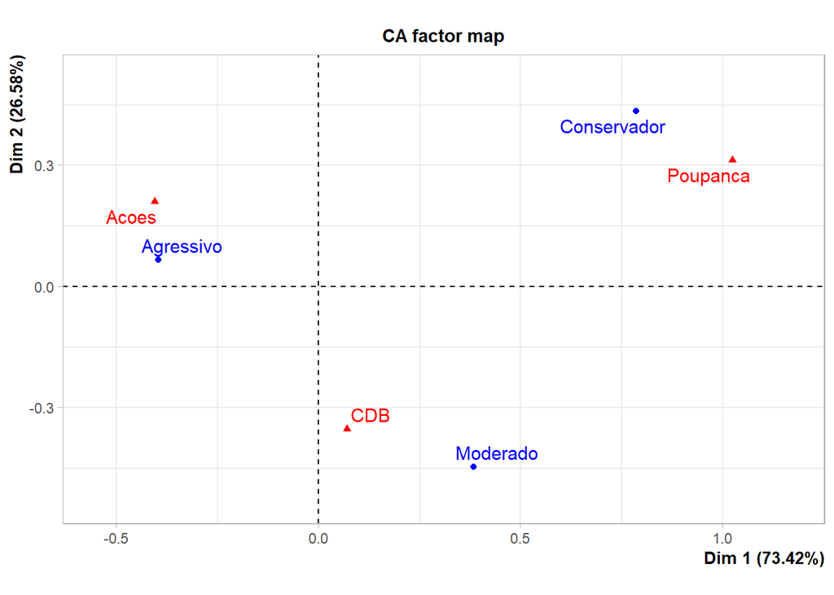

```r
#Direct result by ANACOR
anacor <- CA(contingency_table_CA, graph = TRUE)
```

**Professor’s Comment about the two maps generated**:  
Note que a função ‘CA’ gera um mapa perceptual construído com coordenadas, definidas de maneira diferente em relação às calculadas antes. Entretanto, as proporções das proximidades entre as categorias das variáveis permanecem as mesmas, assim como os percentuais da inércia principal total por dimensão!

# Multiple Correspondence Analysis (MCA)

## Step 0- Knowing my data

```r
dim(perfil_investidor_aplicacao_estadocivil)
```

```
## [1] 100   4
```

```r
for (c in colnames(perfil_investidor_aplicacao_estadocivil)){ #for each col c on the range
                for (i in 1:nrow(perfil_investidor_aplicacao_estadocivil)){ #for each row i on the range
                    if (is.na(perfil_investidor_aplicacao_estadocivil[i,c])) {
                      print (c(c,"NA FOUND"))
                      break #if doesnt work with other coders go change break by next
                    }else{
                      next
                    }
                }
              }
```

No NA found and dimensions are 100 rows and 4 cols.

```r
# Data view
perfil_investidor_aplicacao_estadocivil %>%
  kable() %>%
  kable_styling(bootstrap_options = "striped",
                full_width = FALSE,
                font_size = 20)
```

| estudante | perfil | aplicacao | estado_civil |
| --- | --- | --- | --- |
| Gabriela | Conservador | Poupanca | Casado |
| Luiz Felipe | Conservador | Poupanca | Casado |
| Patrícia | Conservador | Poupanca | Casado |
| Gustavo | Conservador | Poupanca | Solteiro |
| Letícia | Conservador | Poupanca | Casado |
| Ovídio | Conservador | Poupanca | Casado |
| Leonor | Conservador | Poupanca | Casado |
| Dalila | Conservador | Poupanca | Casado |
| Antônio | Conservador | CDB | Casado |
| Júlia | Conservador | CDB | Casado |
| Roberto | Conservador | CDB | Solteiro |
| Renata | Conservador | CDB | Casado |
| Guilherme | Conservador | Acoes | Solteiro |
| Rodrigo | Conservador | Acoes | Solteiro |
| Giulia | Conservador | Acoes | Casado |
| Felipe | Conservador | Acoes | Solteiro |
| Karina | Conservador | Acoes | Casado |
| Pietro | Moderado | Poupanca | Solteiro |
| Cecília | Moderado | Poupanca | Casado |
| Gisele | Moderado | Poupanca | Casado |
| Elaine | Moderado | Poupanca | Casado |
| Kamal | Moderado | Poupanca | Solteiro |
| Rodolfo | Moderado | CDB | Solteiro |
| Pilar | Moderado | CDB | Casado |
| Vivian | Moderado | CDB | Casado |
| Danielle | Moderado | CDB | Casado |
| Juliana | Moderado | CDB | Casado |
| Adriano | Moderado | CDB | Solteiro |
| Adelino | Moderado | CDB | Solteiro |
| Carolina | Moderado | CDB | Casado |

[output cut: 70 more lines]

#### Freq. Table

```r
summary(perfil_investidor_aplicacao_estadocivil)
```

```
##   estudante                 perfil      aplicacao    estado_civil
##  Length:100         Conservador:17   Poupanca:15   Solteiro:57
##  Class :character   Moderado   :25   CDB     :40   Casado  :43
##  Mode  :character   Agressivo  :58   Acoes   :45
```

## Step 1 - contingency table

```r
sjt.xtab(var.row = perfil_investidor_aplicacao_estadocivil$perfil,
         var.col = perfil_investidor_aplicacao_estadocivil$aplicacao,
         show.exp = TRUE,
         show.row.prc = TRUE,
         show.col.prc = TRUE)
```

| perfil | aplicacao |  |  | Total |  |
| --- | --- | --- | --- | --- | --- |
|  | Poupanca | CDB | Acoes |  |  |
| Conservador | 8 3 47.1 % 53.3 % | 4 7 23.5 % 10 % | 5 8 29.4 % 11.1 % |  | 17 17 100 % 17 % |
| Moderado | 5 4 20 % 33.3 % | 16 10 64 % 40 % | 4 11 16 % 8.9 % | 25 25 100 % 25 % |  |
| Agressivo | 2 9 3.4 % 13.3 % | 20 23 34.5 % 50 % | 36 26 62.1 % 80 % | 58 58 100 % 58 % |  |
| Total | 15 15 15 % 100 % | 40 40 40 % 100 % | 45 45 45 % 100 % | 100 100 100 % 100 % |  |

```r
# Perfil x Estado Civil
sjt.xtab(var.row = perfil_investidor_aplicacao_estadocivil$perfil,
         var.col = perfil_investidor_aplicacao_estadocivil$estado_civil,
         show.exp = TRUE,
         show.row.prc = TRUE,
         show.col.prc = TRUE)
```

| perfil | estado_civil |  | Total |  |
| --- | --- | --- | --- | --- |
|  | Solteiro | Casado |  |  |
| Conservador | 5 10 29.4 % 8.8 % | 12 7 70.6 % 27.9 % |  | 17 17 100 % 17 % |
| Moderado | 11 14 44 % 19.3 % | 14 11 56 % 32.6 % | 25 25 100 % 25 % |  |
| Agressivo | 41 33 70.7 % 71.9 % | 17 25 29.3 % 39.5 % | 58 58 100 % 58 % |  |
| Total | 57 57 57 % 100 % | 43 43 43 % 100 % | 100 100 100 % 100 % |  |

```r
# Aplicação x Estado Civil
sjt.xtab(var.row = perfil_investidor_aplicacao_estadocivil$aplicacao,
         var.col = perfil_investidor_aplicacao_estadocivil$estado_civil,
         show.exp = TRUE,
         show.row.prc = TRUE,
         show.col.prc = TRUE)
```

| aplicacao | estado_civil |  | Total |  |
| --- | --- | --- | --- | --- |
|  | Solteiro | Casado |  |  |
| Poupanca | 5 9 33.3 % 8.8 % | 10 6 66.7 % 23.3 % |  | 15 15 100 % 15 % |
| CDB | 16 23 40 % 28.1 % | 24 17 60 % 55.8 % | 40 40 100 % 40 % |  |
| Acoes | 36 26 80 % 63.2 % | 9 19 20 % 20.9 % | 45 45 100 % 45 % |  |
| Total | 57 57 57 % 100 % | 43 43 43 % 100 % | 100 100 100 % 100 % |  |

### Step 2- Binary Matrix or Burt

```r
matrix_bi <- matlogic(perfil_investidor_aplicacao_estadocivil[, 2:4])
matrix_bi
```

```
##     perfil.Agressivo perfil.Conservador perfil.Moderado aplicacao.Acoes
## 1                  1                  0               0               1
## 2                  1                  0               0               1
## 3                  1                  0               0               1
## 4                  1                  0               0               1
## 5                  1                  0               0               1
## 6                  1                  0               0               1
## 7                  1                  0               0               1
## 8                  1                  0               0               1
## 9                  1                  0               0               0
## 10                 1                  0               0               0
## 11                 1                  0               0               0
## 12                 1                  0               0               0
## 13                 1                  0               0               0
## 14                 1                  0               0               0
```

[output cut: 187 more lines]

```r
# Burt
matriz_burt <- burt(perfil_investidor_aplicacao_estadocivil[,2:4])
matriz_burt
```

```
##                       perfil.Agressivo perfil.Conservador perfil.Moderado
## perfil.Agressivo                    17                  0               0
## perfil.Conservador                   0                 25               0
## perfil.Moderado                      0                  0              58
## aplicacao.Acoes                      8                  5               2
## aplicacao.CDB                        4                 16              20
## aplicacao.Poupanca                   5                  4              36
## estado_civil.Casado                  5                 11              41
## estado_civil.Solteiro               12                 14              17
##                       aplicacao.Acoes aplicacao.CDB aplicacao.Poupanca
## perfil.Agressivo                    8             4                  5
## perfil.Conservador                  5            16                  4
## perfil.Moderado                     2            20                 36
## aplicacao.Acoes                    15             0                  0
## aplicacao.CDB                       0            40                  0
## aplicacao.Poupanca                  0             0                 45
## estado_civil.Casado                 5            16                 36
## estado_civil.Solteiro              10            24                  9
##                       estado_civil.Casado estado_civil.Solteiro
## perfil.Agressivo                        5                    12
## perfil.Conservador                     11                    14
## perfil.Moderado                        41                    17
## aplicacao.Acoes                         5                    10
## aplicacao.CDB                          16                    24
## aplicacao.Poupanca                     36                     9
## estado_civil.Casado                    57                     0
## estado_civil.Solteiro                   0                    43
```

Burt also can be done by verifica_burt <- t(matrix_bi) %*% matrix_bi

## MCA Calculations

```r
MCA <- dudi.acm(perfil_investidor_aplicacao_estadocivil[,2:4], scannf = FALSE)
```

### Main categories Cordinates view

**Method 1** : Burt Matrix B (comp. ‘co’ from ‘ACM’ object)

```r
round(MCA$co, 3) %>%
  kable() %>%
  kable_styling(bootstrap_options = "striped",
                full_width = FALSE,
                font_size = 20)
```

|  | Comp1 | Comp2 |
| --- | --- | --- |
| perfil.Conservador | 1.130 | 1.484 |
| perfil.Moderado | 0.747 | -0.975 |
| perfil.Agressivo | -0.653 | -0.015 |
| aplicacao.Poupanca | 1.381 | 1.331 |
| aplicacao.CDB | 0.417 | -0.935 |
| aplicacao.Acoes | -0.831 | 0.388 |
| estado_civil.Solteiro | -0.636 | 0.099 |
| estado_civil.Casado | 0.843 | -0.131 |

**Method 2** : Matrix Binary (comp. ‘c1’ from ‘MCA’ object)

```r
round(MCA$c1, 3) %>%
  kable() %>%
  kable_styling(bootstrap_options = "striped",
                full_width = FALSE,
                font_size = 20)
```

|  | CS1 | CS2 |
| --- | --- | --- |
| perfil.Conservador | 1.456 | 2.247 |
| perfil.Moderado | 0.962 | -1.476 |
| perfil.Agressivo | -0.841 | -0.022 |
| aplicacao.Poupanca | 1.780 | 2.016 |
| aplicacao.CDB | 0.538 | -1.416 |
| aplicacao.Acoes | -1.071 | 0.587 |
| estado_civil.Solteiro | -0.820 | 0.150 |
| estado_civil.Casado | 1.086 | -0.199 |

####Masses for rows and cols.

```r
MCA$cw
```

```
##    perfil.Conservador       perfil.Moderado      perfil.Agressivo
##            0.05666667            0.08333333            0.19333333
##    aplicacao.Poupanca         aplicacao.CDB       aplicacao.Acoes
##            0.05000000            0.13333333            0.15000000
## estado_civil.Solteiro   estado_civil.Casado
##            0.19000000            0.14333333
```

####Eigenvalues, principal inertia

```r
MCA$eig
```

```
## [1] 0.6023045 0.4359878 0.2764728 0.1798371 0.1720645
```

The number of eigen values say that we have 5 dimensions. J-Q = 8-3 = 5

#### Variance percentage explained by dimension

```r
var_perc <- ((MCA$eig)/sum(MCA$eig))*100
var_perc
```

```
## [1] 36.13827 26.15927 16.58837 10.79022 10.32387
```

View var_perc

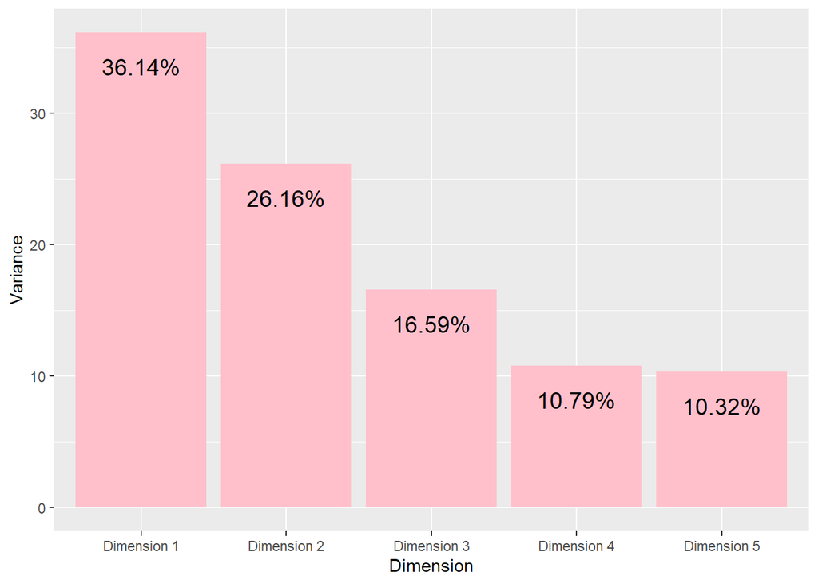

```r
data.frame( Dimension = paste("Dimension", 1:length(var_perc)),
            Variance = var_perc) %>%
  ggplot(aes(x = Dimension,
         y = Variance,
         label = paste0(round(Variance, 2), "%" ))) +
  geom_bar(stat = "identity", fill = "pink") +
  geom_text(vjust = 2.5, size = 5)+
  theme_gray()
```

By the graphic analysis we can notice that 62,3% of the variance is explained at the dimensions 1 and 2.

### Perceptual Map for ACM

Defining categories number

```r
numb_categ <- apply(perfil_investidor_aplicacao_estadocivil[,2:4],
                    MARGIN = 2,
                    FUN = function(x) nlevels(as.factor(x))) # here notice that the var need to be converted to factor for be inputed on nlevel

# Consolidate standard coodinates from Binary Matrix (c1)

df_MCA <- data.frame(MCA$c1, Variable = rep(names(numb_categ), numb_categ))

# View Coord.

df_MCA %>%
  rownames_to_column()%>%
  rename(Category = 1) %>%
  mutate(Category = gsub("perfil", "",Category),
         Category = gsub("aplicacao", "",Category),
         Category = gsub("estado_civil.", "",Category)) %>%
  kable()%>%
  kable_styling(bootstrap_options = "striped",
                full_width = FALSE,
                font_size = 20)
```

| Category | CS1 | CS2 | Variable |
| --- | --- | --- | --- |
| .Conservador | 1.4559917 | 2.2469004 | perfil |
| .Moderado | 0.9621926 | -1.4761295 | perfil |
| .Agressivo | -0.8414944 | -0.0223116 | perfil |
| .Poupanca | 1.7798163 | 2.0160256 | aplicacao |
| .CDB | 0.5375504 | -1.4162527 | aplicacao |
| .Acoes | -1.0710947 | 0.5868828 | aplicacao |
| Solteiro | -0.8195994 | 0.1498337 | estado_civil |
| Casado | 1.0864457 | -0.1986168 | estado_civil |

### Ploting the perceptual map

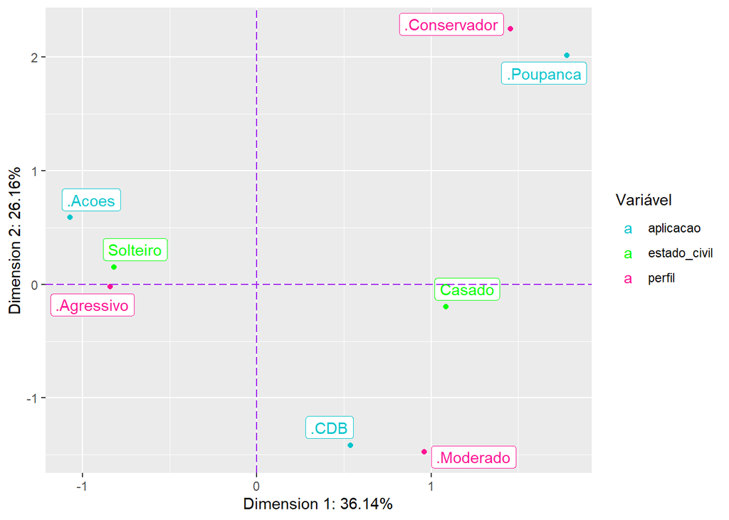

```r
df_MCA %>%
  rownames_to_column()%>%
  rename(Category = 1) %>%
  mutate(Category = gsub("perfil", "",Category),
         Category = gsub("aplicacao", "",Category),
         Category = gsub("estado_civil.", "",Category)) %>%
  ggplot(aes( x = CS1, y = CS2, label = Category, color = Variable)) +
  geom_point()+
  geom_label_repel()+
  geom_vline(aes(xintercept = 0), linetype = "longdash" , color = "purple")+
  geom_hline(aes(yintercept = 0), linetype = "longdash" , color = "purple")+
  labs(x = paste("Dimension 1:", paste0(round(var_perc[1], 2), "%")),
       y = paste ("Dimension 2:", paste0(round(var_perc[2], 2), "%"))) +
  scale_color_manual("Variável",
                     values = c("turquoise3", "green", "deeppink1")) +
  theme_gray()
```

Adding info related to other data set to the map

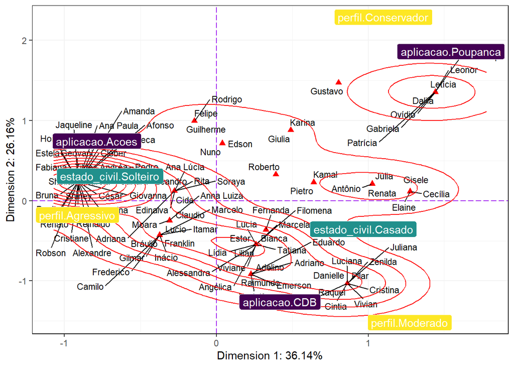

```r
MCA_observartions_df <- MCA$li


MCA_observartions_df %>%
  ggplot(aes(x = Axis1, y = Axis2, label = perfil_investidor_aplicacao$estudante)) +
  geom_point(shape = 17, color = "red", size = 2) +
  geom_vline(aes(xintercept = 0), linetype = "longdash" , color = "purple")+
  geom_hline(aes(yintercept = 0), linetype = "longdash" , color = "purple")+
  geom_text_repel(max.overlaps = 100, size = 3) +
  geom_density2d(color = "red") + # color related to the density lines
  geom_label_repel(data = df_MCA,
                   aes(x = CS1, y = CS2,
                       label = rownames(df_MCA),
                       fill = Variable), # color related to the labels
                   color = "white") +
 labs(x = paste("Dimension 1:", paste0(round(var_perc[1], 2), "%")),
       y = paste ("Dimension 2:", paste0(round(var_perc[2], 2), "%"))) +
  scale_fill_viridis_d() +
  theme(panel.background = element_rect("white"),
        panel.border = element_rect("NA"),
        panel.grid = element_line("gray95"),
        legend.position = "none")
```

By the bidimensional analyses is possible to conclude that investors with Moderate investor’s profile are correlated with CDB investments and Married status. In another hand investments on Stocks are strongly correlated to Agressive investor’s profile and Single marital status.